# 12_Pandas Homework

```python
import pandas as pd
import re
import matplotlib.pyplot as plt
import numpy as np
```

```python
def remove_border(axes=None, top=False, right=False, left=True, bottom=True):
    """
    Minimize chartjunk by stripping out unnecesasry plot borders and axis ticks

    The top/right/left/bottom keywords toggle whether the corresponding plot border is drawn
    """
    ax = axes or plt.gca()
    ax.spines['top'].set_visible(top)
    ax.spines['right'].set_visible(right)
    ax.spines['left'].set_visible(left)
    ax.spines['bottom'].set_visible(bottom)

    #turn off all ticks
    ax.yaxis.set_ticks_position('none')
    ax.xaxis.set_ticks_position('none')

    #now re-enable visibles
    if top:
        ax.xaxis.tick_top()
    if bottom:
        ax.xaxis.tick_bottom()
    if left:
        ax.yaxis.tick_left()
    if right:
        ax.yaxis.tick_right()
```

```python
URL = r'D:\02_Python\temp\00_data\imdb_top_10000.txt'
dt_move_info = pd.read_csv(URL, delimiter = '\t', header = None)
```

## 1. Read data

After loaded data, changing the columns name

```python
old_columns_name = dt_move_info.columns
new_columns_name = ['ID', 'move_name', 'year', 'idbm', 'numbers_review', 'run_time', 'genres']
rename = {x:y for x, y in zip(old_columns_name, new_columns_name)}
dt_move_info.rename(columns = rename, inplace = True)
dt_move_info.head()
```

|  | ID | move_name | year | idbm | numbers_review | run_time | genres |
| --- | --- | --- | --- | --- | --- | --- | --- |
| 0 | tt0111161 | The Shawshank Redemption (1994) | 1994 | 9.2 | 619479 | 142 mins. | Crime\|Drama |
| 1 | tt0110912 | Pulp Fiction (1994) | 1994 | 9.0 | 490065 | 154 mins. | Crime\|Thriller |
| 2 | tt0137523 | Fight Club (1999) | 1999 | 8.8 | 458173 | 139 mins. | Drama\|Mystery\|Thriller |
| 3 | tt0133093 | The Matrix (1999) | 1999 | 8.7 | 448114 | 136 mins. | Action\|Adventure\|Sci-Fi |
| 4 | tt1375666 | Inception (2010) | 2010 | 8.9 | 385149 | 148 mins. | Action\|Adventure\|Sci-Fi\|Thriller |

## 2. Clean the DataFrame

There are several problems with the DataFrame at this point:

The runtime column describes a number, but is stored as a string The genres column is not atomic -- it aggregates several genres together. This makes it hard, for example, to extract which movies are Comedies. The movie year is repeated in the title and year column Fixing the runtime column The following snipptet converts a string like '142 mins.' to the number 142:

Chuyển định dạng columns length qua Int, xóa mins

```python
read_file = pd.read_csv
```

```python
# Kiểm tra data type của các columns
# Cách 1
print(dt_move_info.info())

dt_move_info['run_time_clean'] = dt_move_info.run_time.apply(lambda x: int(re.findall(r'\d+', x)[0]))
print(dt_move_info.info())
```

```
<class 'pandas.core.frame.DataFrame'>
RangeIndex: 10000 entries, 0 to 9999
Data columns (total 7 columns):
ID                10000 non-null object
move_name         10000 non-null object
year              10000 non-null int64
idbm              10000 non-null float64
numbers_review    10000 non-null int64
run_time          10000 non-null object
genres            9999 non-null object
dtypes: float64(1), int64(2), object(4)
memory usage: 547.0+ KB
None
<class 'pandas.core.frame.DataFrame'>
RangeIndex: 10000 entries, 0 to 9999
Data columns (total 8 columns):
ID                10000 non-null object
move_name         10000 non-null object
year              10000 non-null int64
idbm              10000 non-null float64
numbers_review    10000 non-null int64
run_time          10000 non-null object
genres            9999 non-null object
run_time_clean    10000 non-null int64
dtypes: float64(1), int64(3), object(4)
memory usage: 625.1+ KB
None
```

[output not shown]

[output cut: 47 more lines]

```python
a = [123]
type(a[0])
```

```
int
```

```python
# Cach 2

dt_move_info['run_time_clean'] = [float(x.split(' ')[0]) for x in dt_move_info.run_time]
dt_move_info[:5]
```

|  | ID | move_name | year | idbm | numbers_review | run_time | genres | run_time_clean |
| --- | --- | --- | --- | --- | --- | --- | --- | --- |
| 0 | tt0111161 | The Shawshank Redemption (1994) | 1994 | 9.2 | 619479 | 142 mins. | Crime\|Drama | 142.0 |
| 1 | tt0110912 | Pulp Fiction (1994) | 1994 | 9.0 | 490065 | 154 mins. | Crime\|Thriller | 154.0 |
| 2 | tt0137523 | Fight Club (1999) | 1999 | 8.8 | 458173 | 139 mins. | Drama\|Mystery\|Thriller | 139.0 |
| 3 | tt0133093 | The Matrix (1999) | 1999 | 8.7 | 448114 | 136 mins. | Action\|Adventure\|Sci-Fi | 136.0 |
| 4 | tt1375666 | Inception (2010) | 2010 | 8.9 | 385149 | 148 mins. | Action\|Adventure\|Sci-Fi\|Thriller | 148.0 |

## 3.Splitting up the genres

We can use the concept of indicator variables to split the genres column into many columns. Each new column will correspond to a single genre, and each cell will be True or False.

### Stupied ways

```python
genres_split = [set(str(x).split('|')) for x in dt_move_info.genres]
genres_index_uniquee = [set(str(x).split('|')) for x in dt_move_info.genres.unique()]

# Union.
union_genres = set()
for x in genres_index_uniquee:
        union_genres = union_genres | x

tbl_genre = dict()
for col in union_genres:
    temp = [set([col]).issubset(x) for x in genres_split]
    tbl_genre.update({col: temp})

tbl_genre = pd.DataFrame(tbl_genre)
tbl_genre[:4]
```

|  | Action | Adult | Adventure | Animation | Biography | Comedy | Crime | Drama | Family | Fantasy | ... | Mystery | News | Reality-TV | Romance | Sci-Fi | Sport | Thriller | War | Western | nan |
| --- | --- | --- | --- | --- | --- | --- | --- | --- | --- | --- | --- | --- | --- | --- | --- | --- | --- | --- | --- | --- | --- |
| 0 | False | False | False | False | False | False | True | True | False | False | ... | False | False | False | False | False | False | False | False | False | False |
| 1 | False | False | False | False | False | False | True | False | False | False | ... | False | False | False | False | False | False | True | False | False | False |
| 2 | False | False | False | False | False | False | False | True | False | False | ... | True | False | False | False | False | False | True | False | False | False |
| 3 | True | False | True | False | False | False | False | False | False | False | ... | False | False | False | False | True | False | False | False | False | False |

4 rows × 25 columns

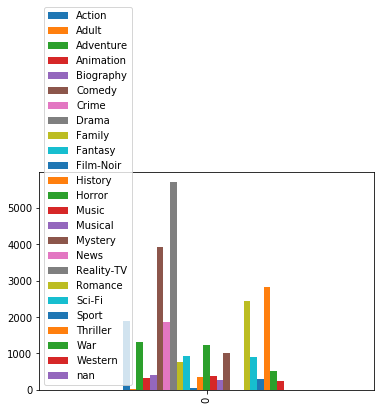

```python
count_genres = dict()

for genres in tbl_genre:
    sum_genres = int(tbl_genre[genres].sum())
    count_genres.update({genres: [sum_genres]})

count_genres = pd.DataFrame(count_genres)
count_genres.plot.bar()
```

[output not shown]

```python
tbl_genre = dict()
for col in union_genres:
    print(type(col))
    break

pd.DataFrame(tbl_genre)
```

```
<class 'str'>
```

```python
temp = {'a':[True, False, True]}
pd.DataFrame(temp)
```

|  | a |
| --- | --- |
| 0 | True |
| 1 | False |
| 2 | True |

### Smarth Ways

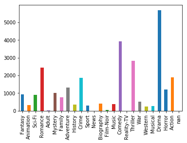

```python
set_genres = set()
for m in dt_move_info.genres:
    set_genres.update(x for x in str(m).split('|'))

dt_move_info_cp = dt_move_info

for genre in set_genres:
    dt_move_info_cp[genre] = [set([genre]).issubset(str(x).split('|')) for x in dt_move_info_cp.genres]

# Đếm tổng số lượng thể loại các bộ phim
dt_move_info_cp[list(set_genres)].sum(). plot.bar()
```

```python
dt_move_info.genres.apply(lambda x: str(x).split('|'))
```

```
0                                        [Crime, Drama]
1                                     [Crime, Thriller]
2                            [Drama, Mystery, Thriller]
3                           [Action, Adventure, Sci-Fi]
4                 [Action, Adventure, Sci-Fi, Thriller]
5                              [Comedy, Drama, Romance]
6                                               [Drama]
7                  [Action, Adventure, Fantasy, Sci-Fi]
8                      [Biography, Drama, History, War]
9                   [Action, Adventure, Family, Sci-Fi]
10                     [Action, Crime, Drama, Thriller]
11                           [Crime, Mystery, Thriller]
12                                    [Crime, Thriller]
13                 [Adventure, Drama, History, Romance]
14             [Action, Biography, Drama, History, War]
```

[output cut: 47 more lines]

## 4.Removing year from the title

The Shawshank Redemption (1994) -> The Shawshank Redemption

```python
dt_move_info_cp = dt_move_info

def delete_year(move_name):
    if re.match(r'.*\(\d\d\d\d\)$', move_name) :
        return move_name[: -6]
    return move_name

dt_move_info_cp.move_name = [delete_year(name)  for name in dt_move_info_cp.move_name]

dt_move_info_cp
```

|  | ID | move_name | year | idbm | numbers_review | run_time | genres | run_time_clean | Fantasy | Animation | ... | Comedy | Reality-TV | Thriller | War | Western | Musical | Drama | Horror | Action | nan |
| --- | --- | --- | --- | --- | --- | --- | --- | --- | --- | --- | --- | --- | --- | --- | --- | --- | --- | --- | --- | --- | --- |
| 0 | tt0111161 | The Shawshank Redemption | 1994 | 9.2 | 619479 | 142 mins. | Crime\|Drama | 142.0 | False | False | ... | False | False | False | False | False | False | True | False | False | False |
| 1 | tt0110912 | Pulp Fiction | 1994 | 9.0 | 490065 | 154 mins. | Crime\|Thriller | 154.0 | False | False | ... | False | False | True | False | False | False | False | False | False | False |
| 2 | tt0137523 | Fight Club | 1999 | 8.8 | 458173 | 139 mins. | Drama\|Mystery\|Thriller | 139.0 | False | False | ... | False | False | True | False | False | False | True | False | False | False |
| 3 | tt0133093 | The Matrix | 1999 | 8.7 | 448114 | 136 mins. | Action\|Adventure\|Sci-Fi | 136.0 | False | False | ... | False | False | False | False | False | False | False | False | True | False |
| 4 | tt1375666 | Inception | 2010 | 8.9 | 385149 | 148 mins. | Action\|Adventure\|Sci-Fi\|Thriller | 148.0 | False | False | ... | False | False | True | False | False | False | False | False | True | False |
| 5 | tt0109830 | Forrest Gump | 1994 | 8.7 | 368994 | 142 mins. | Comedy\|Drama\|Romance | 142.0 | False | False | ... | True | False | False | False | False | False | True | False | False | False |
| 6 | tt0169547 | American Beauty | 1999 | 8.6 | 338332 | 122 mins. | Drama | 122.0 | False | False | ... | False | False | False | False | False | False | True | False | False | False |
| 7 | tt0499549 | Avatar | 2009 | 8.1 | 336855 | 162 mins. | Action\|Adventure\|Fantasy\|Sci-Fi | 162.0 | True | False | ... | False | False | False | False | False | False | False | False | True | False |
| 8 | tt0108052 | Schindler's List | 1993 | 8.9 | 325888 | 195 mins. | Biography\|Drama\|History\|War | 195.0 | False | False | ... | False | False | False | True | False | False | True | False | False | False |
| 9 | tt0080684 | Star Wars: Episode V - The Empire Strikes Back | 1980 | 8.8 | 320105 | 124 mins. | Action\|Adventure\|Family\|Sci-Fi | 124.0 | False | False | ... | False | False | False | False | False | False | False | False | True | False |
| 10 | tt0372784 | Batman Begins | 2005 | 8.3 | 316613 | 140 mins. | Action\|Crime\|Drama\|Thriller | 140.0 | False | False | ... | False | False | True | False | False | False | True | False | True | False |
| 11 | tt0114814 | The Usual Suspects | 1995 | 8.7 | 306624 | 106 mins. | Crime\|Mystery\|Thriller | 106.0 | False | False | ... | False | False | True | False | False | False | False | False | False | False |
| 12 | tt0102926 | The Silence of the Lambs | 1991 | 8.7 | 293081 | 118 mins. | Crime\|Thriller | 118.0 | False | False | ... | False | False | True | False | False | False | False | False | False | False |
| 13 | tt0120338 | Titanic | 1997 | 7.4 | 284245 | 194 mins. | Adventure\|Drama\|History\|Romance | 194.0 | False | False | ... | False | False | False | False | False | False | True | False | False | False |
| 14 | tt0112573 | Braveheart | 1995 | 8.4 | 281446 | 177 mins. | Action\|Biography\|Drama\|History\|War | 177.0 | False | False | ... | False | False | False | True | False | False | True | False | True | False |
| 15 | tt0167404 | The Sixth Sense | 1999 | 8.2 | 278210 | 107 mins. | Drama\|Mystery\|Thriller | 107.0 | False | False | ... | False | False | True | False | False | False | True | False | False | False |
| 16 | tt0266697 | Kill Bill: Vol. 1 | 2003 | 8.2 | 272983 | 111 mins. | Action\|Crime\|Thriller | 111.0 | False | False | ... | False | False | True | False | False | False | False | False | True | False |
| 17 | tt0099685 | Goodfellas | 1990 | 8.8 | 270728 | 146 mins. | Biography\|Crime\|Drama\|Thriller | 146.0 | False | False | ... | False | False | True | False | False | False | True | False | False | False |
| 18 | tt0416449 | 300 | 2006 | 7.8 | 269328 | 117 mins. | Action\|Fantasy\|History\|War | 117.0 | True | False | ... | False | False | False | True | False | False | False | False | True | False |
| 19 | tt0482571 | The Prestige | 2006 | 8.4 | 258396 | 130 mins. | Drama\|Mystery\|Thriller | 130.0 | False | False | ... | False | False | True | False | False | False | True | False | False | False |
| 20 | tt0105236 | Reservoir Dogs | 1992 | 8.4 | 247390 | 99 mins. | Crime\|Mystery\|Thriller | 99.0 | False | False | ... | False | False | True | False | False | False | False | False | False | False |
| 21 | tt0110413 | Leon: The Professional | 1994 | 8.6 | 244568 | 110 mins. | Crime\|Drama\|Thriller | 110.0 | False | False | ... | False | False | True | False | False | False | True | False | False | False |
| 22 | tt0120689 | The Green Mile | 1999 | 8.4 | 243660 | 189 mins. | Crime\|Drama\|Fantasy\|Mystery | 189.0 | True | False | ... | False | False | False | False | False | False | True | False | False | False |
| 23 | tt0361748 | Inglourious Basterds | 2009 | 8.4 | 240995 | 153 mins. | Adventure\|Drama\|War | 153.0 | False | False | ... | False | False | False | True | False | False | True | False | False | False |
| 24 | tt0910970 | WALL\xb7E | 2008 | 8.5 | 229364 | 98 mins. | Animation\|Adventure\|Family\|Romance\|Sci-Fi | 98.0 | False | True | ... | False | False | False | False | False | False | False | False | False | False |
| 25 | tt0468569 | The Dark Knight | 2008 | 8.9 | 555122 | 152 mins. | Action\|Crime\|Drama\|Thriller | 152.0 | False | False | ... | False | False | True | False | False | False | True | False | True | False |
| 26 | tt0068646 | The Godfather | 1972 | 9.2 | 474189 | 175 mins. | Crime\|Drama | 175.0 | False | False | ... | False | False | False | False | False | False | True | False | False | False |
| 27 | tt0120737 | The Lord of the Rings: The Fellowship of the R... | 2001 | 8.8 | 451263 | 178 mins. | Action\|Adventure\|Drama\|Fantasy | 178.0 | True | False | ... | False | False | False | False | False | False | True | False | True | False |
| 28 | tt0167260 | The Lord of the Rings: The Return of the King | 2003 | 8.8 | 428791 | 201 mins. | Action\|Adventure\|Drama\|Fantasy | 201.0 | True | False | ... | False | False | False | False | False | False | True | False | True | False |
| 29 | tt0167261 | The Lord of the Rings: The Two Towers | 2002 | 8.7 | 383113 | 179 mins. | Action\|Adventure\|Drama\|Fantasy | 179.0 | True | False | ... | False | False | False | False | False | False | True | False | True | False |
| ... | ... | ... | ... | ... | ... | ... | ... | ... | ... | ... | ... | ... | ... | ... | ... | ... | ... | ... | ... | ... | ... |
| 9970 | tt0469897 | Diggers | 2006 | 6.4 | 1358 | 96 mins. | Comedy\|Drama | 96.0 | False | False | ... | True | False | False | False | False | False | True | False | False | False |
| 9971 | tt0110064 | House Party 3 | 1994 | 3.1 | 1357 | 100 mins. | Comedy\|Music\|Romance | 100.0 | False | False | ... | True | False | False | False | False | False | False | False | False | False |
| 9972 | tt1629391 | Tere Bin Laden | 2010 | 7.2 | 1357 | 95 mins. | Comedy\|Drama | 95.0 | False | False | ... | True | False | False | False | False | False | True | False | False | False |
| 9973 | tt0878674 | Garage | 2007 | 6.9 | 1356 | 00 mins. | Drama | 0.0 | False | False | ... | False | False | False | False | False | False | True | False | False | False |
| 9974 | tt0076391 | Mimino | 1977 | 8.2 | 1356 | 97 mins. | Comedy | 97.0 | False | False | ... | True | False | False | False | False | False | False | False | False | False |
| 9975 | tt1316037 | Birdemic: Shock and Terror | 2008 | 2.0 | 1366 | 90 mins. | Horror\|Romance\|Thriller | 90.0 | False | False | ... | False | False | True | False | False | False | False | True | False | False |
| 9976 | tt0197094 | What Becomes of the Broken Hearted? | 1999 | 6.3 | 1365 | 00 mins. | Drama | 0.0 | False | False | ... | False | False | False | False | False | False | True | False | False | False |
| 9977 | tt0092608 | Back to the Beach | 1987 | 5.1 | 1364 | 92 mins. | Comedy | 92.0 | False | False | ... | True | False | False | False | False | False | False | False | False | False |
| 9978 | tt0093175 | Hello Again | 1987 | 4.5 | 1364 | 96 mins. | Comedy\|Drama\|Fantasy\|Romance | 96.0 | True | False | ... | True | False | False | False | False | False | True | False | False | False |
| 9979 | tt1034320 | Major Movie Star | 2008 | 3.8 | 1364 | 98 mins. | Adventure\|Comedy\|Drama\|War | 98.0 | False | False | ... | True | False | False | True | False | False | True | False | False | False |
| 9980 | tt0066476 | The Touch of Satan | 1971 | 2.0 | 1364 | 90 mins. | Horror | 90.0 | False | False | ... | False | False | False | False | False | False | False | True | False | False |
| 9981 | tt1281374 | Don McKay | 2009 | 6.0 | 1363 | 87 mins. | Drama\|Thriller\|Mystery | 87.0 | False | False | ... | False | False | True | False | False | False | True | False | False | False |
| 9982 | tt0263124 | Brainstorm | 2001 | 7.8 | 1362 | 74 mins. | Drama | 74.0 | False | False | ... | False | False | False | False | False | False | True | False | False | False |
| 9983 | tt0368259 | Sex Lives of the Potato Men | 2004 | 4.3 | 1362 | 82 mins. | Comedy | 82.0 | False | False | ... | True | False | False | False | False | False | False | False | False | False |
| 9984 | tt0067333 | Lawman | 1971 | 6.8 | 1362 | 99 mins. | Western | 99.0 | False | False | ... | False | False | False | False | True | False | False | False | False | False |
| 9985 | tt0065669 | The Dunwich Horror | 1970 | 5.1 | 1361 | 90 mins. | Horror | 90.0 | False | False | ... | False | False | False | False | False | False | False | True | False | False |
| 9986 | tt0048198 | I Live in Fear | 1955 | 7.3 | 1360 | 103 mins. | Drama | 103.0 | False | False | ... | False | False | False | False | False | False | True | False | False | False |
| 9987 | tt0100046 | The Long Walk Home | 1990 | 7.2 | 1360 | 97 mins. | Drama\|History | 97.0 | False | False | ... | False | False | False | False | False | False | True | False | False | False |
| 9988 | tt0116247 | Evil Ed | 1995 | 5.0 | 1359 | 93 mins. | Horror\|Comedy | 93.0 | False | False | ... | True | False | False | False | False | False | False | True | False | False |
| 9989 | tt0101356 | Another You | 1991 | 4.9 | 1359 | 98 mins. | Comedy\|Crime | 98.0 | False | False | ... | True | False | False | False | False | False | False | False | False | False |
| 9990 | tt0421090 | Zerophilia | 2005 | 6.3 | 1359 | 90 mins. | Comedy\|Romance | 90.0 | False | False | ... | True | False | False | False | False | False | False | False | False | False |
| 9991 | tt0067227 | The Merchant of Four Seasons | 1971 | 7.6 | 1359 | 88 mins. | Drama | 88.0 | False | False | ... | False | False | False | False | False | False | True | False | False | False |
| 9992 | tt0339727 | Stateside | 2004 | 5.8 | 1358 | 97 mins. | Drama\|Music\|Romance | 97.0 | False | False | ... | False | False | False | False | False | False | True | False | False | False |
| 9993 | tt0218581 | Scarlet Diva | 2000 | 5.2 | 1358 | 91 mins. | Drama | 91.0 | False | False | ... | False | False | False | False | False | False | True | False | False | False |
| 9994 | tt0118635 | Aprile | 1998 | 6.7 | 1358 | 78 mins. | Comedy | 78.0 | False | False | ... | True | False | False | False | False | False | False | False | False | False |
| 9995 | tt0807721 | Meduzot | 2007 | 7.0 | 1357 | 78 mins. | Drama | 78.0 | False | False | ... | False | False | False | False | False | False | True | False | False | False |
| 9996 | tt0339642 | Daltry Calhoun | 2005 | 5.2 | 1357 | 100 mins. | Comedy\|Drama\|Music\|Romance | 100.0 | False | False | ... | True | False | False | False | False | False | True | False | False | False |
| 9997 | tt0060880 | The Quiller Memorandum | 1966 | 6.5 | 1356 | 104 mins. | Drama\|Mystery\|Thriller | 104.0 | False | False | ... | False | False | True | False | False | False | True | False | False | False |
| 9998 | tt0152836 | Taal | 1999 | 6.5 | 1356 | 179 mins. | Musical\|Romance | 179.0 | False | False | ... | False | False | False | False | False | True | False | False | False | False |
| 9999 | tt0279977 | The Navigators | 2001 | 6.9 | 1356 | 96 mins. | Comedy\|Drama | 96.0 | False | False | ... | True | False | False | False | False | False | True | False | False | False |

10000 rows × 33 columns

```python
a = [1,2,3,4]
a[-2 :]
```

```
[3, 4]
```

```python
a = 'as;lkdlaasdasskldlas2)'
if re.match(r'.*\(\d\d\d\d\)$', a):
    print(a[:-6])
else:
    print(a)
```

```
as;lkdlaasdasskldlas2)
```

## 5 Describle Data

```python
dt_move_info_cp.describe
```

[output not shown]

[output cut: 301 more lines]

```python
dt_move_info_cp[['year', 'idbm', 'numbers_review', 'run_time_clean']].describe()
```

|  | year | idbm | numbers_review | run_time_clean |
| --- | --- | --- | --- | --- |
| count | 10000.000000 | 10000.000000 | 10000.000000 | 10000.000000 |
| mean | 1993.472800 | 6.386070 | 16604.012800 | 103.578400 |
| std | 14.829924 | 1.189933 | 34563.459698 | 26.628698 |
| min | 1950.000000 | 1.500000 | 1356.000000 | 0.000000 |
| 25% | 1986.000000 | 5.700000 | 2333.750000 | 93.000000 |
| 50% | 1998.000000 | 6.600000 | 4980.500000 | 102.000000 |
| 75% | 2005.000000 | 7.200000 | 15277.750000 | 115.000000 |
| max | 2011.000000 | 9.200000 | 619479.000000 | 450.000000 |

```python
a = set('Adventure')
aa = 'Action|Adventure|Fantasy|Sci-Fi'.split('|')
a.issubset(aa)
```

```
False
```

```
5.1 Check nan
```

```python
dt_move_info_cp.isna().sum()[:10]
```

```
ID                0
move_name         0
year              0
idbm              0
numbers_review    0
run_time          0
genres            1
run_time_clean    0
Fantasy           0
Animation         0
dtype: int64
```

### 6. Draw chart

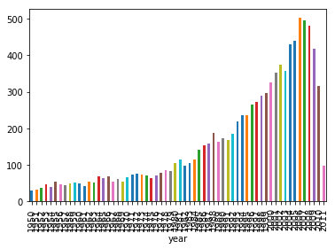

```python
dt_move_info_cp.groupby('year').count().ID.plot.bar()
```

[output not shown]

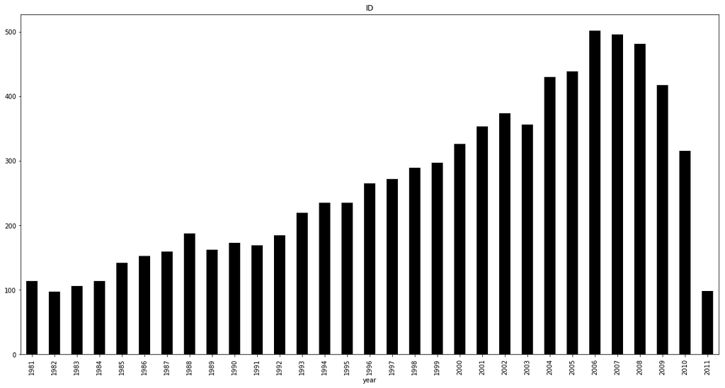

```python
pd.set_option('display.width', 1000)
pd.set_option('display.max_columns', 100)
dt_move_info_cp[dt_move_info_cp.year > 1980].groupby('year').count().ID.plot(kind = 'bar', color='black', subplots = True, figsize = (20, 10))
```

```python
pd.Data
```

### kind : Định dạng chart

- line : line plot (default)
- bar : vertical bar plot
- barh : horizontal bar plot
- hist : histogram
- box : boxplot
- kde : Kernel Density Estimation plot
- density : same as kde
- area : area plot
- pie : pie plot
- scatter : scatter plot
- hexbin : hexbin plot

### figsize = (20, 10) : Kích thước chart, theo inch

### Color = ('black') : Màu chart

### 2. Vẽ chart thể hiện điểm IDBM

Bins = 20. Giá trị được chia 20 khoảng, các giá trị tương đương sẽ được chia vào các nhóm tương đương

```
[]
```

[figure not shown]

```python
dt_move_info_cp.idbm

idbm_round = [round(x) for x in dt_move_info_cp.idbm]
plt.plot()
```

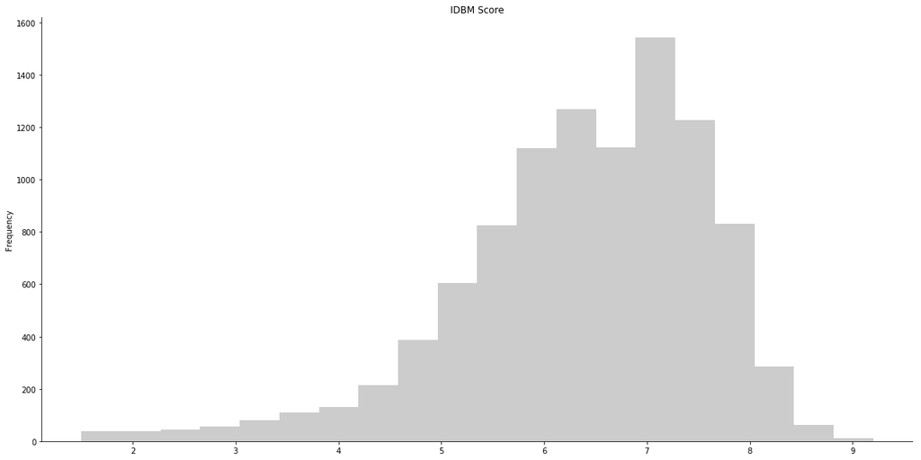

```python
dt_move_info_cp.idbm.plot.hist(figsize = (20, 10), bins = 20, color = '#cccccc', title = 'IDBM Score')
remove_border()
```

### 3 .Vẽ chart thể hiện runtime

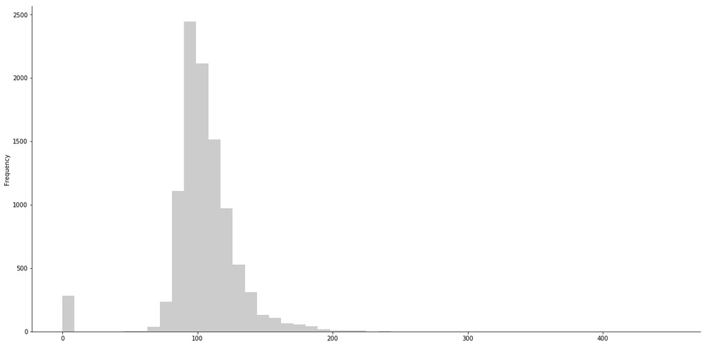

```python
dt_move_info_cp.run_time_clean.plot.hist(color = '#cccccc', bins = 50, figsize = (20,10))
remove_border()
```

### 4. Biểu đồ scarter thể hiện điểm IMDB qua các năm

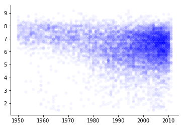

```python
plt_idbm = plt.scatter(dt_move_info_cp.year, dt_move_info_cp.idbm, lw = 0, alpha=.04, color='b')
remove_border()
#plt.scatter(data.year, data.score, lw=0, alpha=.08, color='k')
```

### 5. Scater thể hiện số lượng Votes, cùng IMBD

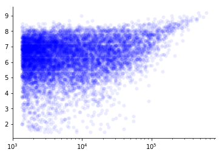

```python
plt.scatter(dt_move_info_cp.numbers_review, dt_move_info_cp.idbm, lw = 0, alpha=.08, color='b')
remove_border()
plt.xscale('log')
```

# 7. Thao tác trên Data

```python
dt_move_info_cp[(dt_move_info.numbers_review > 10e4) & (dt_move_info.idbm > 8)][['move_name', 'year', 'idbm', 'numbers_review']][:20]
```

|  | move_name | year | idbm | numbers_review |
| --- | --- | --- | --- | --- |
| 0 | The Shawshank Redemption | 1994 | 9.2 | 619479 |
| 1 | Pulp Fiction | 1994 | 9.0 | 490065 |
| 2 | Fight Club | 1999 | 8.8 | 458173 |
| 3 | The Matrix | 1999 | 8.7 | 448114 |
| 4 | Inception | 2010 | 8.9 | 385149 |
| 5 | Forrest Gump | 1994 | 8.7 | 368994 |
| 6 | American Beauty | 1999 | 8.6 | 338332 |
| 7 | Avatar | 2009 | 8.1 | 336855 |
| 8 | Schindler's List | 1993 | 8.9 | 325888 |
| 9 | Star Wars: Episode V - The Empire Strikes Back | 1980 | 8.8 | 320105 |
| 10 | Batman Begins | 2005 | 8.3 | 316613 |
| 11 | The Usual Suspects | 1995 | 8.7 | 306624 |
| 12 | The Silence of the Lambs | 1991 | 8.7 | 293081 |
| 14 | Braveheart | 1995 | 8.4 | 281446 |
| 15 | The Sixth Sense | 1999 | 8.2 | 278210 |
| 16 | Kill Bill: Vol. 1 | 2003 | 8.2 | 272983 |
| 17 | Goodfellas | 1990 | 8.8 | 270728 |
| 19 | The Prestige | 2006 | 8.4 | 258396 |
| 20 | Reservoir Dogs | 1992 | 8.4 | 247390 |
| 21 | Leon: The Professional | 1994 | 8.6 | 244568 |

### 7.2 In ra danh sách những bộ phim có idbm thấp nhât

```python
dt_move_info_cp[dt_move_info_cp.idbm == dt_move_info_cp.idbm.min()]
```

|  | ID | move_name | year | idbm | numbers_review | run_time | genres | run_time_clean | Fantasy | Animation | Sci-Fi | Romance | Adult | Mystery | Family | Adventure | History | Crime | Sport | News | Biography | Film-Noir | Music | Comedy | Reality-TV | Thriller | War | Western | Musical | … |
| --- | --- | --- | --- | --- | --- | --- | --- | --- | --- | --- | --- | --- | --- | --- | --- | --- | --- | --- | --- | --- | --- | --- | --- | --- | --- | --- | --- | --- | --- | --- |
| 1982 | tt0060666 | Manos: The Hands of Fate | 1966 | 1.5 | 20927 | 74 mins. | Horror | 74.0 | False | False | False | False | False | False | False | False | False | False | False | False | False | False | False | False | False | False | False | False | False | … |
| 2793 | tt0270846 | Superbabies: Baby Geniuses 2 | 2004 | 1.5 | 13196 | 88 mins. | Comedy\|Family | 88.0 | False | False | False | False | False | False | True | False | False | False | False | False | False | False | False | True | False | False | False | False | False | … |
| 3746 | tt0421051 | Daniel the Wizard | 2004 | 1.5 | 8271 | 81 mins. | Comedy\|Crime\|Family\|Fantasy\|Horror | 81.0 | True | False | False | False | False | False | True | False | False | True | False | False | False | False | False | True | False | False | False | False | False | … |
| 5158 | tt0364986 | Ben & Arthur | 2002 | 1.5 | 4675 | 85 mins. | Drama\|Romance | 85.0 | False | False | False | True | False | False | False | False | False | False | False | False | False | False | False | False | False | False | False | False | False | … |
| 5993 | tt0060753 | Night Train to Mundo Fine | 1966 | 1.5 | 3542 | 89 mins. | Action\|Adventure\|Crime\|War | 89.0 | False | False | False | False | False | False | False | True | False | True | False | False | False | False | False | False | False | False | True | False | False | … |
| 6257 | tt0059464 | Monster a-Go Go | 1965 | 1.5 | 3255 | 70 mins. | Sci-Fi\|Horror | 70.0 | False | False | True | False | False | False | False | False | False | False | False | False | False | False | False | False | False | False | False | False | False | … |
| 6726 | tt1309000 | Dream Well | 2009 | 1.5 | 2848 | 00 mins. | Comedy\|Romance\|Sport | 0.0 | False | False | False | True | False | False | False | False | False | False | True | False | False | False | False | True | False | False | False | False | False | … |

### 7.3 Danh sách bộ phim có IDBM cao nhất

```python
dt_move_info_cp[dt_move_info_cp.idbm == dt_move_info_cp.idbm.max()]
```

|  | ID | move_name | year | idbm | numbers_review | run_time | genres | run_time_clean | Fantasy | Animation | Sci-Fi | Romance | Adult | Mystery | Family | Adventure | History | Crime | Sport | News | Biography | Film-Noir | Music | Comedy | Reality-TV | Thriller | War | Western | Musical | … |
| --- | --- | --- | --- | --- | --- | --- | --- | --- | --- | --- | --- | --- | --- | --- | --- | --- | --- | --- | --- | --- | --- | --- | --- | --- | --- | --- | --- | --- | --- | --- |
| 0 | tt0111161 | The Shawshank Redemption | 1994 | 9.2 | 619479 | 142 mins. | Crime\|Drama | 142.0 | False | False | False | False | False | False | False | False | False | True | False | False | False | False | False | False | False | False | False | False | False | … |
| 26 | tt0068646 | The Godfather | 1972 | 9.2 | 474189 | 175 mins. | Crime\|Drama | 175.0 | False | False | False | False | False | False | False | False | False | True | False | False | False | False | False | False | False | False | False | False | False | … |

```python
dt_move_info_cp[(dt_move_info_cp.idbm > 8) & (dt_move_info_cp.year > 2000) & (dt_move_info_cp.year < 1994)]
```

|  | ID | move_name | year | idbm | numbers_review | run_time | genres | run_time_clean | Fantasy | Animation | Sci-Fi | Romance | Adult | Mystery | Family | Adventure | History | Crime | Sport | News | Biography | Film-Noir | Music | Comedy | Reality-TV | Thriller | War | Western | Musical | … |
| --- | --- | --- | --- | --- | --- | --- | --- | --- | --- | --- | --- | --- | --- | --- | --- | --- | --- | --- | --- | --- | --- | --- | --- | --- | --- | --- | --- | --- | --- | --- |

### 7.5 Tính tổng số lượng trong nhóm các thể loại phim, sắp xếp theo thứ tự giảm dần

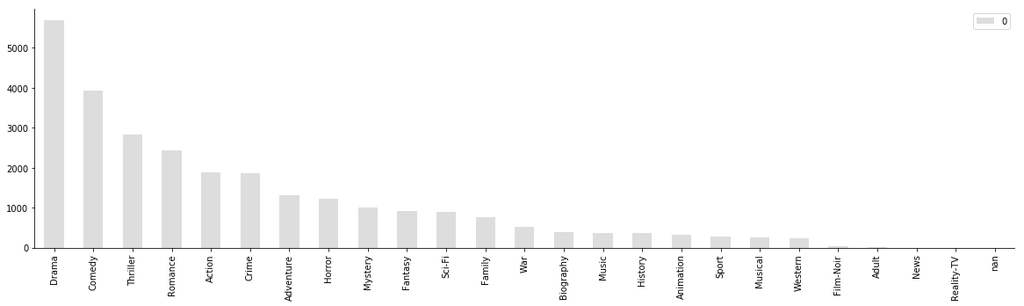

```python
# Step 1 : Lấy danh sách các thể loại phim, sử dụng set update
dt_move_info_cp.genres
genres_set = set()
for x in dt_move_info_cp.genres:
    genres_set.update(str(x).split('|'))

# Step 2 ; Tính tổng các thể loại phim
values = dt_move_info_cp[list(genres_set)].sum()

# Step 3 : Sắp xếp theo thứ tự tăng dần
values.sort_values(ascending = False, inplace=True)

pd.DataFrame(values).plot.bar(figsize = (20, 5), color = '#dddddd')

remove_border()
```

## 8. Phân tích nâng cao

### 8.1 Vẽ biểu đồ Scarter (Year, IMDB), vẽ Line chart cho Means(IMDB)

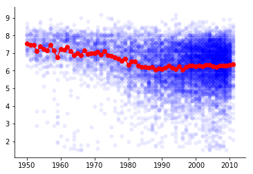

```python
# Step 1. Tính Means imdb
mean_idbm = dt_move_info_cp[['year', 'idbm']].groupby('year').mean()

# Step 2. Sort theo index, tức sort theo năm theo thứ tự năm tăng dần
mean_idbm.sort_index()

# Step 3. Vẽ line chart cho mean_idbm theo year
plt.plot(mean_idbm, 'ro-')

# Step 4. Vẽ scater chart cho imdb theo year
plt.scatter(dt_move_info_cp.year,
            dt_move_info_cp.idbm,
            lw = 0,
            alpha=.08,
            color='b'
           )

remove_border()
```

```python
mean_idbm.plot.line?
```